# Ford Gobike Exploration

## by Rahal Mehdi Abdelaziz

## Investigation Overview

> In this investigation, I wanted to explore when are most trips taken in term of time of day, day of week or month, I also wanted to explore trip duration regarding the same last time features, and see if it is influenced by if a user is a member or a casual customer.

## Dataset Overview

**Nb :** The exploration will be done regarding time of day, day of week and the month>

## Total number of trip

> Periods with the most number of trips:
- Day of Time : from 08:00 to 10:00 and from 16:00 to 19:00.
- Day of Week : Tuesday, Wednesday ,Thursday and Friday, Monday is slightly lower and the weekend have a low total number of trip.
- Months : February 2020 is the with the highest total number.

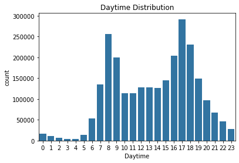

```python
base_color = sb.color_palette()[0];

######
sb.countplot(data=df, x='daytime', color = base_color);
plt.xlabel('Daytime');
plt.title('Daytime Distribution');
```

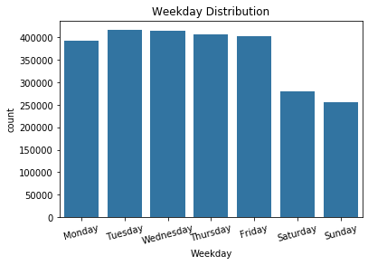

```python
sb.countplot(data=df, x='weekday', color=base_color);
plt.xticks(rotation = 15);
plt.xlabel('Weekday');
plt.title('Weekday Distribution');
```

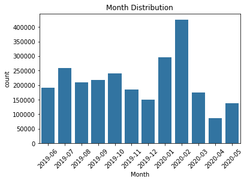

```python
sb.countplot(data=df, x ='month', color=base_color);
plt.xticks(rotation = 45);
plt.xlabel('Month');
plt.title('Month Distribution');
```

## The average trip duration

> The average trip duration is about 10 minutes, I refered to the median due to outliers.  
> The average is higher on the weekend ( regarding day of week) and the last two months (regarding months) wich coincide with the corona virus pandemic.  
> Another observation is the negative correlation between the trip duration average and the total trip count.

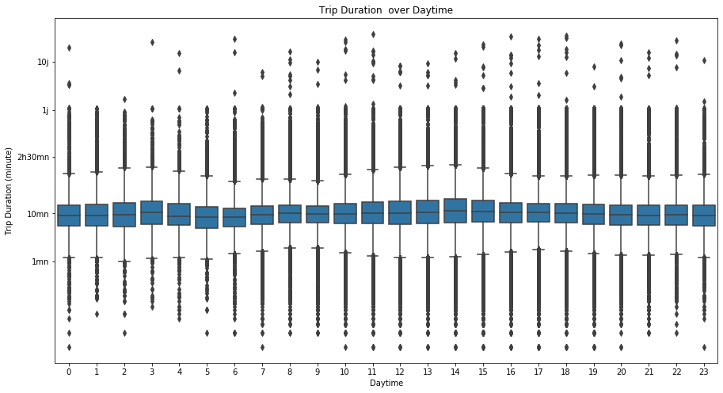

```python
plt.figure(figsize=(15,8))
sb.boxplot(data = df, x = 'daytime', y = 'trip_duration_exp', color=base_color);
# set y ticks and labels
duration_yticks();
plt.xlabel('Daytime');
plt.ylabel('Trip Duration (minute)');
plt.title('Trip Duration  over Daytime');
```

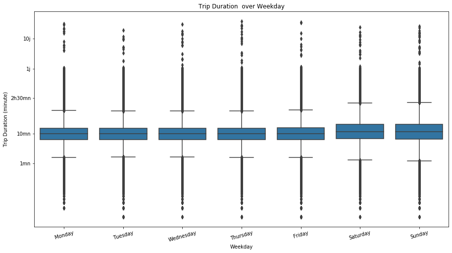

```python
plt.figure(figsize=(15,8))
sb.boxplot(data = df, x = 'weekday', y = 'trip_duration_exp', color=base_color);
# set y ticks and labels
duration_yticks();

plt.xticks(rotation = 15);
plt.xlabel('Weekday');
plt.ylabel('Trip Duration (minute)');
plt.title('Trip Duration  over Weekday');
```

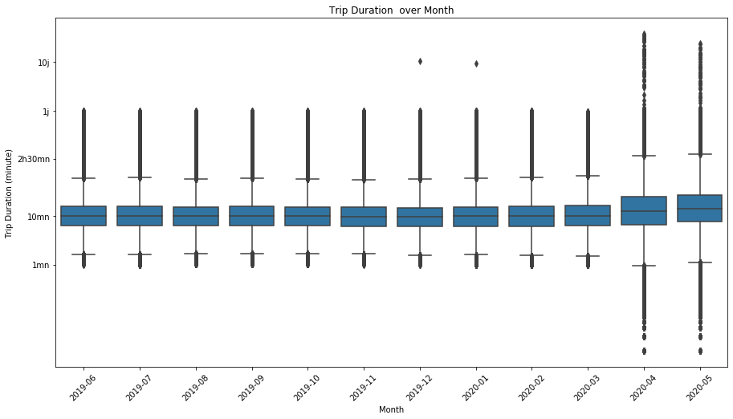

```python
plt.figure(figsize=(15,8))
sb.boxplot(data = df, x = 'month', y = 'trip_duration_exp', color=base_color);
# set y ticks and labels
duration_yticks();

plt.xticks(rotation = 45);
plt.xlabel('Month');
plt.ylabel('Trip Duration (minute)');
plt.title('Trip Duration  over Month');
```

## Total number of trip

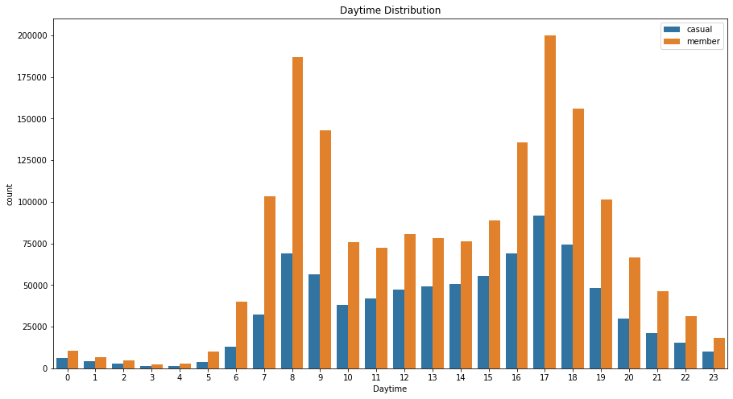

```python
plt.figure(figsize=(15,8))
sb.countplot(data=df, x='daytime', hue='member_casual' );
plt.xlabel('Daytime');
plt.title('Daytime Distribution')
plt.legend(title=None);
```

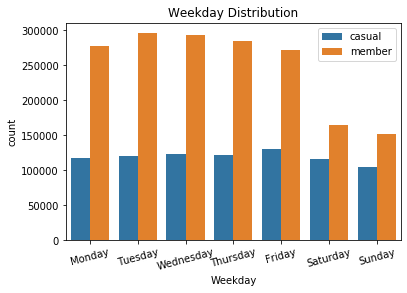

```python
sb.countplot(data=df, x='weekday', hue='member_casual');
plt.xticks(rotation = 15);
plt.xlabel('Weekday')
plt.title('Weekday Distribution')
plt.legend(title=None);
```

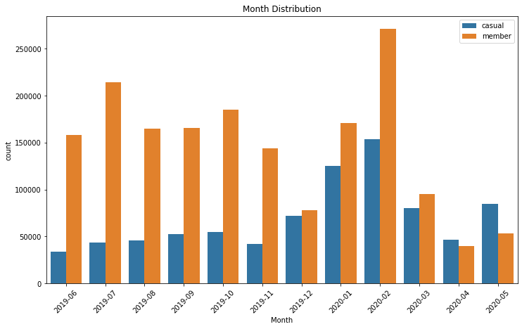

```python
plt.figure(figsize=(12,7))
sb.countplot(data=df, x ='month', hue='member_casual');
plt.xticks(rotation = 45);
plt.xlabel('Month')
plt.title('Month Distribution')
plt.legend(title=None);
```

## Trip Duration by Customer type

> Casual customer are more susceptible to have a long trip.

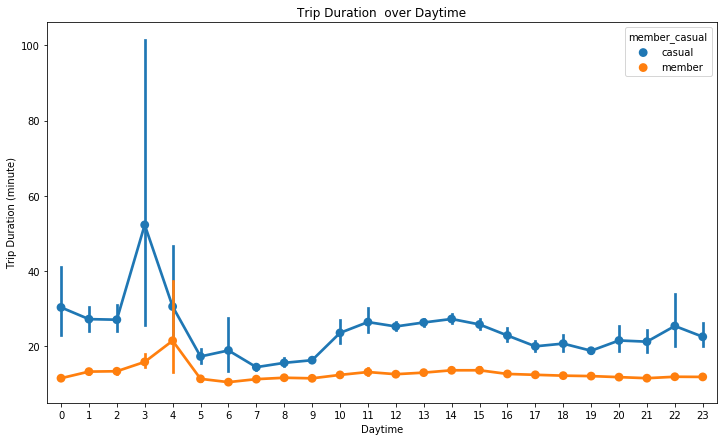

```python
plt.figure(figsize=(12,7))

sb.pointplot(data = df, x = 'daytime', y = 'trip_duration', hue='member_casual');
plt.xlabel('Daytime');
plt.ylabel('Trip Duration (minute)');
plt.title('Trip Duration  over Daytime');
```

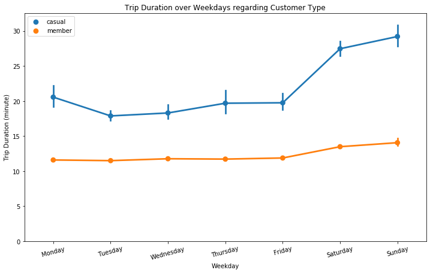

```python
####### Weekday
plt.figure(figsize=(12,7))
sb.pointplot(data=df, x='weekday', y='trip_duration', hue='member_casual');
plt.xticks(rotation = 15);
plt.legend(loc=2);
plt.xlabel('Weekday');
plt.ylabel('Trip Duration (minute)');
plt.title('Trip Duration over Weekdays regarding Customer Type');
plt.ylim(0,32.5)
plt.show()
```

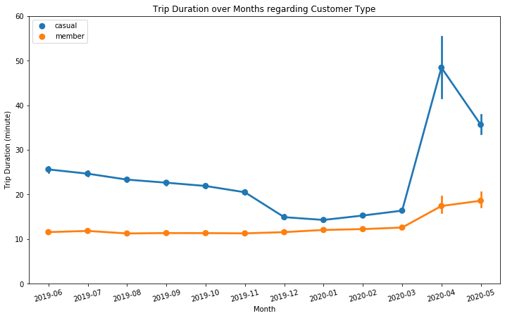

```python
####### Month
plt.figure(figsize=(12,7))
sb.pointplot(data=df, x='month', y='trip_duration', hue='member_casual');
plt.xticks(rotation = 15);
plt.legend(loc=2);
plt.xlabel('Month');
plt.ylabel('Trip Duration (minute)');
plt.title('Trip Duration over Months regarding Customer Type');
plt.ylim(0,60)
plt.show()
```